# Regresiones lineales

Author

Betsy Cohen

## Modelado

Un modelo siempre es una reconstrucción simplificada de como está funcionando un proceso. En data siempre vamos a tener al menos:

Una variable resultante o la **depenediente**

Una o varias variables predictoras o **explicativas**

Identificarlo no siempre es fácil por eso siempre esta bueno formularlo como pregunta.

El modelado de datos puede ser utilizado para dos propósitos:

1. **Predecir** el valor de una variable dependiente en base a valores conocidos de las variables predictoras: **cómo** las variables interactúan entre sí o **por qué** lo hacen.
2. **Explicar** la relación entre una variable dependiente y todas las demás (explicativas) para ver si es una relación significativa o no.

## Elige tu propia aventura

Cuando tengamos que analizar una relación entre una variable dependiente métrica y un conjunto de variables que pueden o no ser métricas.

Por ej. ¿En qué medida influyen las variables de interés de nuestro dataset en el Producto Bruto Geográfico?

[figure not shown]

## Limpieza antes de arrancar

Para poder hacer cualquier analisis antes de arrancar asumimos que los datos ya fueron trabajados respecto de su preparación básica es decir:

- tratamiento de casos nulos, ver si los perdidos tienen algún patron (con por ej `mice::mdpattern()`)
- trabajo con outliers
- eliminación de casos duplicados
- variables que contienen información duplicadas
- escalado de variables que requieran el valor

## Regresión lineal simple

Arranquemos por entender la expresión más simple de la regresión lineal: la regresión lineal simple.

Tenemos nuestra variable y, numérica, y una sola variable predictora x, que puede ser numérica o categórica.

Vamos a ponerlo en práctica con nuestros datos de juguete.

```r
# Cargamos las librerías necesarias
library(tidyverse)
library(readxl)
library(janitor)
library(broom)
library(car)
library(lmtest)
library(ggplot2)
```

```r
# Leemos la base desde Excel
df_pbg <- read_excel("data_raw/R Base Betsy.xlsx", sheet = "revisadoTablaseparaluminaria") %>%
  clean_names()


# Seleccionamos las columnas de interés (al menos las que vamos a usar al principio)
df_pbg_subset <- df_pbg %>%
  select(ano_firma,cliente,tipo_de_bien_agrupado,montos_a_oct_24,montos_en_millones_a_oct_24,partido_politico,periodo_de_gestion,pbg_valores_2023_constantes,impuestos,valor_agregado_bruto,total_productores_de_bienes,total_productores_de_servicios)

# observamos las variables
str(df_pbg_subset)
```

```
tibble [27 × 12] (S3: tbl_df/tbl/data.frame)
 $ ano_firma                     : num [1:27] 2020 2020 2020 2020 2020 ...
 $ cliente                       : chr [1:27] "MUNICIPALIDAD DE A" "MUNICIPALIDAD DE A" "MUNICIPALIDAD DE A" "MUNICIPALIDAD DE A" ...
 $ tipo_de_bien_agrupado         : chr [1:27] "Tractor" "Camión Compactador" "Camión Volcador" "Pick Up" ...
 $ montos_a_oct_24               : num [1:27] 1.09e+08 1.35e+08 1.10e+08 2.80e+07 1.90e+07 ...
 $ montos_en_millones_a_oct_24   : num [1:27] 109 135 110 28 19 ...
 $ partido_politico              : chr [1:27] "Partido Justicialista" "Partido Justicialista" "Partido Justicialista" "Partido Justicialista" ...
 $ periodo_de_gestion            : chr [1:27] "Período 2020-2023" "Período 2020-2023" "Período 2020-2023" "Período 2020-2023" ...
 $ pbg_valores_2023_constantes   : num [1:27] 7.3e+08 7.3e+08 7.3e+08 7.3e+08 7.3e+08 ...
 $ impuestos                     : logi [1:27] NA NA NA NA NA NA ...
 $ valor_agregado_bruto          : num [1:27] 6.42e+08 6.42e+08 6.42e+08 6.42e+08 6.42e+08 ...
 $ total_productores_de_bienes   : num [1:27] 3.98e+08 3.98e+08 3.98e+08 3.98e+08 3.98e+08 ...
 $ total_productores_de_servicios: num [1:27] 2.44e+08 2.44e+08 2.44e+08 2.44e+08 2.44e+08 ...
```

chequeamos su distribución y si hay casos faltantes

```r
df_pbg_subset %>%
  mutate(across(where(is.character), as.factor)) %>%
  summary()
```

```
   ano_firma                      cliente          tipo_de_bien_agrupado
 Min.   :2017   MUNICIPALIDAD DE A    : 6   Luminaria         :10
 1st Qu.:2017   MUNICIPALIDAD DE A A  : 1   Camión            : 4
 Median :2017   MUNICIPALIDAD DE AAB  : 1   Furgón            : 2
 Mean   :2018   MUNICIPALIDAD DE AABC : 6   Camión Compactador: 1
 3rd Qu.:2018   MUNICIPALIDAD DE AABCD:13   Camión Volcador   : 1
 Max.   :2024                               Computadora       : 1
                                            (Other)           : 8
 montos_a_oct_24     montos_en_millones_a_oct_24              partido_politico
 Min.   :  9092448   Min.   :  9.092             Juntos por el Cambio :15
 1st Qu.:109420577   1st Qu.:109.421             Partido Justicialista:12
 Median :168408238   Median :168.408
 Mean   :274484862   Mean   :274.485
 3rd Qu.:588205067   3rd Qu.:588.205
 Max.   :865144124   Max.   :865.144

         periodo_de_gestion pbg_valores_2023_constantes impuestos
 Período 2016-2019:20       Min.   :5.752e+08           Mode:logical
 Período 2020-2023: 6       1st Qu.:7.296e+08           NA's:27
 Período 2024-2027: 1       Median :4.736e+09
                            Mean   :4.366e+09
                            3rd Qu.:4.736e+09
                            Max.   :8.466e+09

 valor_agregado_bruto total_productores_de_bienes
 Min.   :4.821e+08    Min.   :2.680e+08
 1st Qu.:6.417e+08    1st Qu.:3.976e+08
 Median :3.933e+09    Median :1.283e+09
 Mean   :3.598e+09    Mean   :1.238e+09
 3rd Qu.:3.933e+09    3rd Qu.:1.283e+09
 Max.   :6.868e+09    Max.   :2.305e+09

 total_productores_de_servicios
 Min.   :2.140e+08
 1st Qu.:2.441e+08
 Median :2.650e+09
 Mean   :2.360e+09
 3rd Qu.:2.650e+09
 Max.   :4.563e+09
```

> Pregunta central: ¿En qué medida el monto invertido por municipio (montos_a_oct_24) influye sobre el Producto Bruto Geográfico a precios constantes 2023 (pbg_valores_2023_constantes)?

**Variable dependiente:** Producto Bruto Geográfico a precios constantes 2023

**Variables independientes** : Montos a Oct 2024

Hipótesis nula (H₀): El monto no tiene efecto significativo sobre el PBG. Hipótesis alternativa (H₁): El monto tiene efecto significativo sobre el PBG.

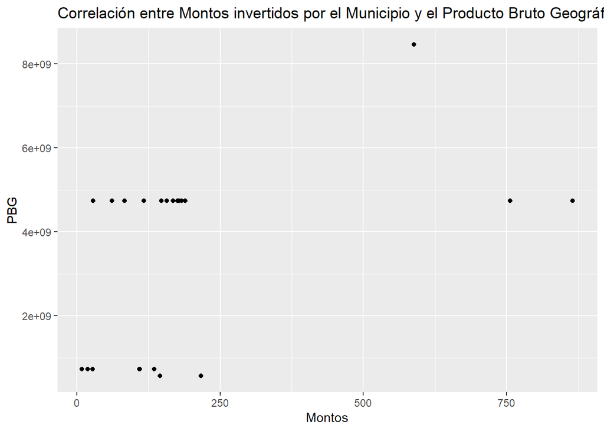

```r
df_pbg_subset %>%
  ggplot()+
  geom_point(aes(x = montos_en_millones_a_oct_24, y = pbg_valores_2023_constantes))+
  labs(title = "Correlación entre Montos invertidos por el Municipio y el Producto Bruto Geográfico",
       x = "Montos",
       y = "PBG")
```

Vamos a medir la correlación entre ambas variables

```r
cor(df_pbg_subset$montos_en_millones_a_oct_24,df_pbg_subset$pbg_valores_2023_constantes)
```

```
[1] 0.6730181
```

**¿A partir de qué valor consideramos que existe una correlación apreciable?**

- de 0,7 a 1: de fuerte a total
- de 0,6 a 0,5: de moderada a fuerte
- de 0,4 a 0,3: de débil a moderada
- menor a 0,3: de nula a débil

En principio la relación para esta muestra no parece ser lineal. Para corroborarlo vamos a hacer un modelo de regresión lineal simple

```r
# Creamos el modelo
modelo_1 <- lm(data = df_pbg_subset, pbg_valores_2023_constantes ~ montos_en_millones_a_oct_24)

# vemos los resultados
modelo_1
```

```
Call:
lm(formula = pbg_valores_2023_constantes ~ montos_en_millones_a_oct_24,
    data = df_pbg_subset)

Coefficients:
                (Intercept)  montos_en_millones_a_oct_24
                  2.312e+09                    7.482e+06
```

**¿Y esto cómo lo leo?**

**Si el modelo fuera lineal** (que no lo es y ahora vamos a terminar de ver cómo comprobarlo) podríamos decir que por cada peso adicional invertido en el municipio (medido en montos_a_oct_24), se estima un incremento de $7.48 en el PBG a precios constantes.

El `intercetp` nos dice en donde se están interceptando las variables y básicamente nos sirve (o le sirve a R) para trazar esa linea de predicción para los datos que justamente no aparecen allí.

y = a + b × x

A cada punto en **x** le corresponde un valor en **y** que se obtiene multiplicando a **x** por la pendiente, **b** , y sumando la intersección, **a**.

Volviendo a nuestro ejemplo y para de paso aprender un truquito de visualización de con ggplot

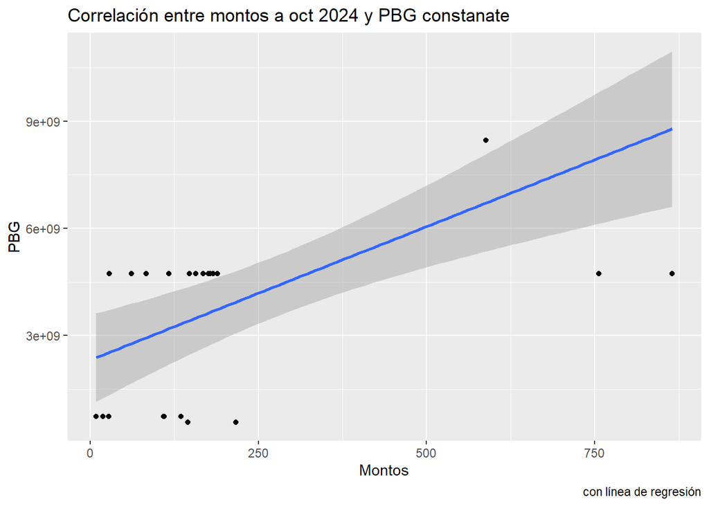

```r
ggplot(data = df_pbg_subset) +
    geom_point(aes(x = montos_en_millones_a_oct_24  , y = pbg_valores_2023_constantes)) +
    labs(title = "Correlación entre montos a oct 2024 y PBG constanate",
       x = "Montos",
       y = "PBG",
       caption = "con línea de regresión") +
    geom_smooth(aes(x = montos_en_millones_a_oct_24, y = pbg_valores_2023_constantes), method = "lm")
```

### ¿Qué tiene que cumplir nuestro modelo para ser lineal?

1. Normalidad de residuos

Las predicciones te informan los patrones que el modelo captura y los residuos te dicen lo que el modelo ignora.

Los residuos son justamente esas distancias entre lo observado y los valores predichos que calculamos anteriormente.

Cuando los residuos son pequeños decimos que nuestro modelo se ajusta bien a los datos observados y sino es tiempo de buscar otro modelo que represente mejor esta relación.

Realizamos un gráfico qq para comprobar la linealidad de los residuos respecto de los quantiles

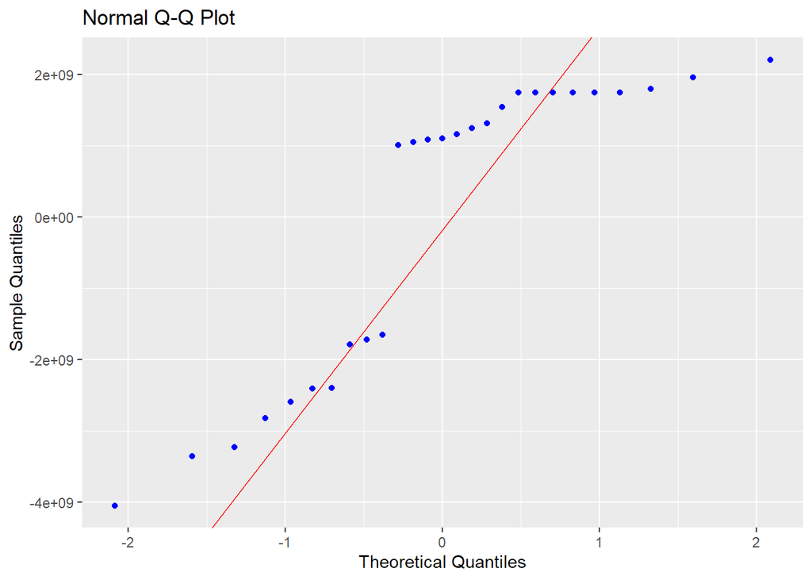

```r
olsrr::ols_plot_resid_qq(modelo_1)
```

Para evaluar esta normalidad tenemos el test de Shapiro-Wilk y Se plantea como hipótesis nula que una muestra proviene de una población normalmente distribuida.

Siendo la hipótesis nula que la población está distribuida normalmente, si el p-valor es menor a alfa (nivel de significancia que por lo general es 0,05) entonces la hipótesis nula es rechazada (se concluye que los datos no vienen de una distribución normal). Si el p-valor es mayor a alfa, se concluye que no se puede rechazar dicha hipótesis.

```r
# Normalidad de residuos
shapiro.test(residuals(modelo_1))
```

```
    Shapiro-Wilk normality test

data:  residuals(modelo_1)
W = 0.80043, p-value = 0.0001392
```

2. Heterocedasticidad

Debemos constatar es que la varianza de los residuos se distribuyen homogéneamente y tienen media 0 (homoscedasticidad) Para que se cumpla el supuesto de homocedasticidad de los errores se necesita que los puntos se ubiquen como una nube de puntos sin ningún patrón claro. Cualquier patrón que se observe es evidencia de que no se cumple el supuesto de homocedasticidad de los errores.

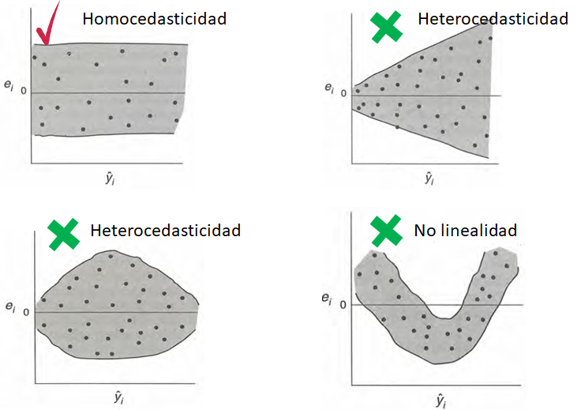

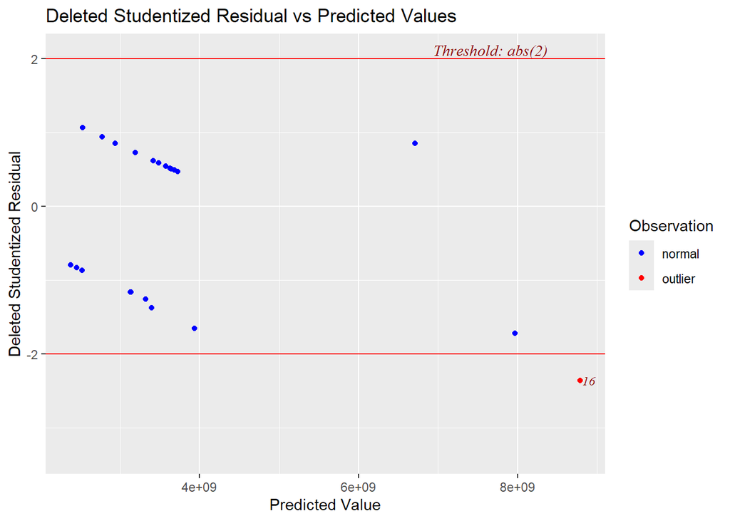

```r
olsrr::ols_plot_resid_stud_fit(modelo_1)
```

```r
lmtest::bptest(modelo_1)
```

```
    studentized Breusch-Pagan test

data:  modelo_1
BP = 4.3979, df = 1, p-value = 0.03598
```

3. Multicolinealidad

La multicolinealidad tiene sentido en modelos donde interviene más de dos variables basicamente es la correlación directa entre las dos variables (por ej. una variable deriva de la otra como en el caso de monto en millones y montos)

Para medirla se usa la función vif (tolerance and variance inflation factors).

Los factores de inflación de la varianza miden la inflación de las varianzas de las estimaciones de los parámetros debido a las colineales existentes entre los predictores. Es una medida de la varianza del coeficiente de regresión estimado. se infla por la existencia de correlación entre las variables predictoras del modelo. Un VIF de 1 significa que no hay correlación entre el k-ésimo predictor y las variables predictoras restantes, y, por lo tanto, la varianza de No está inflado en absoluto. La regla general es que los VIF superiores a 4 justifican una investigación más profunda, mientras que los VIF superiores a 10 indican una multicolinealidad grave que requiere corrección.

```r
#olsrr::ols_vif_tol(modelo_1)
```

**NotePaquetes para evaluar tu modelo**

Existen diferentes paquetes que te permiten evaluar estos puntos uno de ellos es `performance`

## Regresión múltiple

En la regresión lineal múltiple vamos a incorporar una cantidad arbitraria de variables al modelo, buscando representar las múltiples dinámicas que inciden en el fenómeno estudiado. Vamos a empezar con las variables cuanti y después vamos a ver un ejemplo de cómo incorporar las cuali.

```r
glimpse(df_pbg_subset)
```

```
Rows: 27
Columns: 12
$ ano_firma                      <dbl> 2020, 2020, 2020, 2020, 2020, 2020, 201…
$ cliente                        <chr> "MUNICIPALIDAD DE A", "MUNICIPALIDAD DE…
$ tipo_de_bien_agrupado          <chr> "Tractor", "Camión Compactador", "Camió…
$ montos_a_oct_24                <dbl> 108986223, 134820675, 109854931, 279660…
$ montos_en_millones_a_oct_24    <dbl> 108.986223, 134.820675, 109.854931, 27.…
$ partido_politico               <chr> "Partido Justicialista", "Partido Justi…
$ periodo_de_gestion             <chr> "Período 2020-2023", "Período 2020-2023…
$ pbg_valores_2023_constantes    <dbl> 729617608, 729617608, 729617608, 729617…
$ impuestos                      <lgl> NA, NA, NA, NA, NA, NA, NA, NA, NA, NA,…
$ valor_agregado_bruto           <dbl> 641719428, 641719428, 641719428, 641719…
$ total_productores_de_bienes    <dbl> 397627736, 397627736, 397627736, 397627…
$ total_productores_de_servicios <dbl> 244091692, 244091692, 244091692, 244091…
```

Vamos a sumar a nuestro modelo además de montos_a_oct_24 el valor_agregado_bruto, total_productores_de_bienes y total_productores_de_servicios, De paso vamos a ver un clásico caso de colinealidad

```r
modelo_2 <- lm(pbg_valores_2023_constantes ~ montos_a_oct_24 + valor_agregado_bruto +
   total_productores_de_bienes + total_productores_de_servicios,
   data = df_pbg_subset)
summary(modelo_2)
```

```
Call:
lm(formula = pbg_valores_2023_constantes ~ montos_a_oct_24 +
    valor_agregado_bruto + total_productores_de_bienes + total_productores_de_servicios,
    data = df_pbg_subset)

Residuals:
      Min        1Q    Median        3Q       Max
-28405569 -15250746  -4479057   8931694  72883476

Coefficients: (1 not defined because of singularities)
                                 Estimate Std. Error t value Pr(>|t|)
(Intercept)                    -1.724e+08  1.449e+07 -11.901 2.61e-11 ***
montos_a_oct_24                 3.378e-02  2.636e-02   1.282    0.213
valor_agregado_bruto            1.046e+00  2.520e-02  41.534  < 2e-16 ***
total_productores_de_bienes     6.169e-01  8.336e-02   7.400 1.59e-07 ***
total_productores_de_servicios         NA         NA      NA       NA
---
Signif. codes:  0 '***' 0.001 '**' 0.01 '*' 0.05 '.' 0.1 ' ' 1

Residual standard error: 24790000 on 23 degrees of freedom
Multiple R-squared:  0.9999,    Adjusted R-squared:  0.9999
F-statistic: 1.143e+05 on 3 and 23 DF,  p-value: < 2.2e-16
```

total_productores_de_servicios Es probable que valor_agregado_bruto sea la suma de total_productores_de_bienes y total_productores_de_servicios. Vamos a chequear:

```r
df_pbg_subset$valor_agregado_bruto ==
    df_pbg_subset$total_productores_de_bienes + df_pbg_subset$total_productores_de_servicios
```

```
 [1] TRUE TRUE TRUE TRUE TRUE TRUE TRUE TRUE TRUE TRUE TRUE TRUE TRUE TRUE TRUE
[16] TRUE TRUE TRUE TRUE TRUE TRUE TRUE TRUE TRUE TRUE TRUE TRUE
```

Esto suguiere que no deberíamos incluirlo en nuestro modelo así que vamos de nuevo pero sin esta variable

```r
modelo_2 <- lm(pbg_valores_2023_constantes ~ montos_a_oct_24 +  valor_agregado_bruto, data = df_pbg_subset)
summary(modelo_2)
```

```
Call:
lm(formula = pbg_valores_2023_constantes ~ montos_a_oct_24 +
    valor_agregado_bruto, data = df_pbg_subset)

Residuals:
      Min        1Q    Median        3Q       Max
-91066435 -33537442  16458510  46065116  57808437

Coefficients:
                       Estimate Std. Error t value Pr(>|t|)
(Intercept)          -8.829e+07  1.616e+07  -5.462  1.3e-05 ***
montos_a_oct_24       8.189e-02  4.598e-02   1.781   0.0876 .
valor_agregado_bruto  1.232e+00  5.120e-03 240.580  < 2e-16 ***
---
Signif. codes:  0 '***' 0.001 '**' 0.01 '*' 0.05 '.' 0.1 ' ' 1

Residual standard error: 44620000 on 24 degrees of freedom
Multiple R-squared:  0.9998,    Adjusted R-squared:  0.9998
F-statistic: 5.291e+04 on 2 and 24 DF,  p-value: < 2.2e-16
```

El resumen incluye los parámetros que definieron al modelo, los valores por cuartil de los residuos, y una tabla con variables numéricas

`Estimate` nos dice el el “efecto” estimado de cada variable explicativa sobre la dependiente (los famosos coeficientes que vimos con la regresion lineal simple)

Nuestro R Cuadrado es super alto puede ser que el pbg_valores_2023_constantes este correlacionado o en espejo con valor_agregado_bruto?

```r
cor(df_pbg_subset$pbg_valores_2023_constantes, df_pbg_subset$valor_agregado_bruto)
```

```
[1] 0.9998716
```

Pareciera que sí. Sin embargo a pesar de ello la tolerancia se mantiene por debajo de 10 (que es lo reciomendable)

```r
olsrr::ols_vif_tol(modelo_2)
```

```
             Variables Tolerance      VIF
1      montos_a_oct_24 0.5523918 1.810309
2 valor_agregado_bruto 0.5523918 1.810309
```

El tema es que valor_agregado_bruto está prácticamente determinando el PBG porque lo compone o se construye con él.

Una solución aquí sería poder sumar otras variables cuanti como por ej.

- tazas de empleo registrado
- exportaciones/importaciones
- inversión en infraestructura
- cantidad impuestos recaudados

## Metiendo variables cuali

Supongamos que queremos saber si hay una relación entre los periodos de gesytion y el pbg

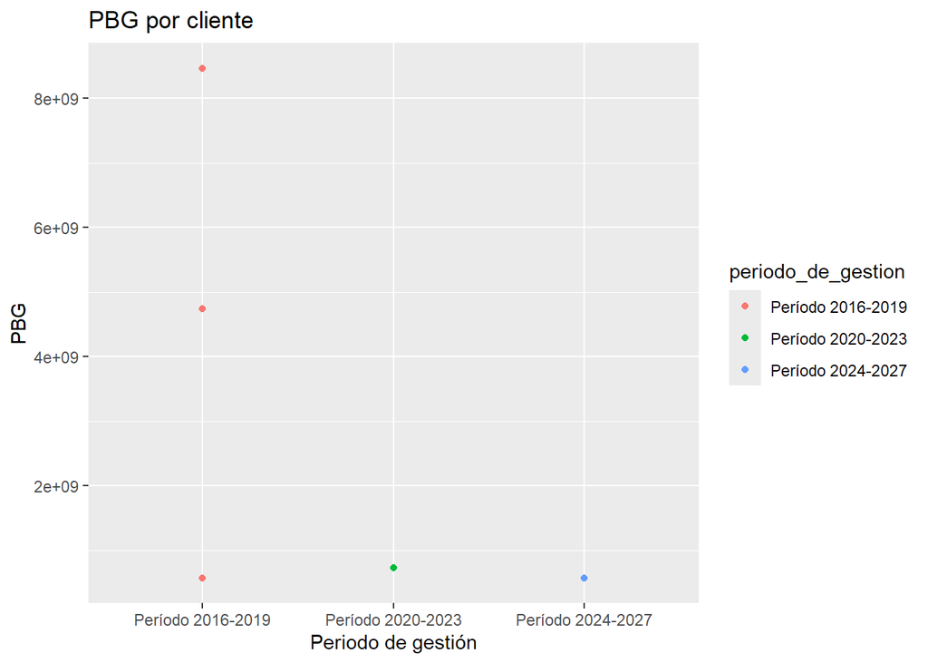

```r
ggplot(data = df_pbg_subset) +
    geom_point(aes(x = periodo_de_gestion, y = pbg_valores_2023_constantes, color = periodo_de_gestion)) +
    labs(title = "PBG por cliente",
         x = "Periodo de gestión",
         y = "PBG")
```

Ya por este gráfico podemos ver que no todos los clientes tienen el mismo PBG. Vamos a “cuantificar” esta relación

```r
modelo_3 <- lm(pbg_valores_2023_constantes ~ periodo_de_gestion, data = df_pbg_subset)

modelo_3
```

```
Call:
lm(formula = pbg_valores_2023_constantes ~ periodo_de_gestion,
    data = df_pbg_subset)

Coefficients:
                        (Intercept)  periodo_de_gestionPeríodo 2020-2023
                          5.647e+09                           -4.917e+09
periodo_de_gestionPeríodo 2024-2027
                         -5.071e+09
```

¿Entonces como lo interpretamos?

```r
summary(modelo_3)
```

```
Call:
lm(formula = pbg_valores_2023_constantes ~ periodo_de_gestion,
    data = df_pbg_subset)

Residuals:
       Min         1Q     Median         3Q        Max
-5.071e+09 -9.109e+08 -9.109e+08  0.000e+00  2.819e+09

Coefficients:
                                      Estimate Std. Error t value Pr(>|t|)
(Intercept)                          5.647e+09  4.188e+08  13.483 1.08e-12 ***
periodo_de_gestionPeríodo 2020-2023 -4.917e+09  8.718e+08  -5.640 8.31e-06 ***
periodo_de_gestionPeríodo 2024-2027 -5.071e+09  1.919e+09  -2.643   0.0143 *
---
Signif. codes:  0 '***' 0.001 '**' 0.01 '*' 0.05 '.' 0.1 ' ' 1

Residual standard error: 1.873e+09 on 24 degrees of freedom
Multiple R-squared:  0.6004,    Adjusted R-squared:  0.5671
F-statistic: 18.03 on 2 and 24 DF,  p-value: 1.656e-05
```

O visto de otra forma

(Intercept): 5.647e+09 → El PBG promedio (a valores constantes 2023) en el Período 2016–2019 fue $5.647 mil millones.

Período 2020–2023: -4.917e+09 → En este período, el PBG promedio fue $4.917 mil millones menor que en 2016–2019.

Período 2024–2027: -5.071e+09 → En este período, el PBG promedio fue $5.071 mil millones menor que en 2016–2019.

Y si lo quisieramos poner en un informe podríamos poner algo asi como

> El modelo muestra una caída promedio significativa del PBG a valores constantes durante los períodos 2020–2023 y 2024–2027, en comparación con 2016–2019. La magnitud de la caída ronda los $5 mil millones en ambos casos, lo que indica un retroceso persistente en la actividad económica medida por este indicador.

## Bibliografía de consulta

- [Antonio Vazquez Brust - Capítulo 5 Modelado estadístico en “Ciencia de Datos para Gente Sociable”](https://bitsandbricks.github.io/ciencia_de_datos_gente_sociable/modelado-estad%C3%ADstico.html)
- [Francisco Urdinez y Andrés Cruz Labrín (Editores) - Capítulo 5 Modelos lineales - en “AnalizaR Datos Políticos”](https://arcruz0.github.io/libroadp/linear.html)
- [Análisis Multivariante aplicado con R Joaquin Aldas Ezequiel Uriel](https://drive.google.com/file/d/16n2f5edlOkuPqb5EFbu76Th5jfKMx9lT/view?usp=sharing)